# Stat 545 Lecture Notes

# Lecture 6

This lecture is about ggplot2.

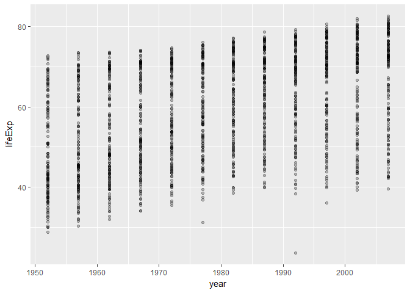

```r
#load library
library(ggplot2)
library(gapminder)

#create first layer that contains dataset and an indication of what variables will go to what scale
p <- ggplot(gapminder, aes(x=year, y=lifeExp))

#this is blank as you need to layer on points and asthetics which is done using a "+"
p + geom_point(alpha=0.25)
```

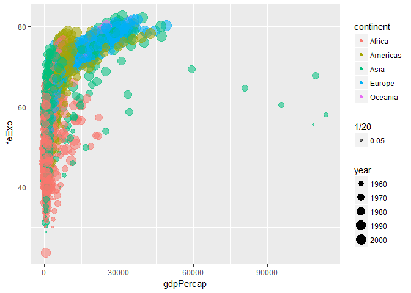

```r
#make a scatterplot of GDP per capita and life expectancy
p2 <- ggplot(gapminder, aes(x=gdpPercap, y=lifeExp))
p2+ geom_point(aes(size=year, color=continent, alpha=1/20))
```

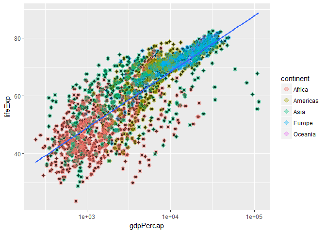

```r
#log transformation
p3 <- p2 + geom_point() + scale_x_log10()

#Colour log transformation by continent and set transparency and size
p4 <- p3 + geom_point(aes(color = continent), alpha=(1/3), size=3)

#Add a smooth line without standard error and using lm
p4 + geom_smooth(method=lm, se = FALSE)
```

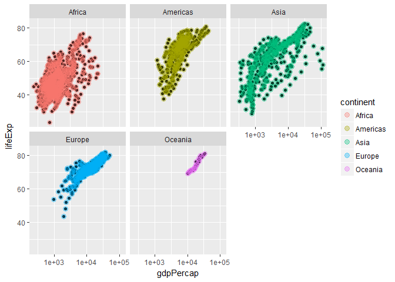

```r
#Take advantage of facetting (factoring)
p4 + facet_wrap(~continent)
```

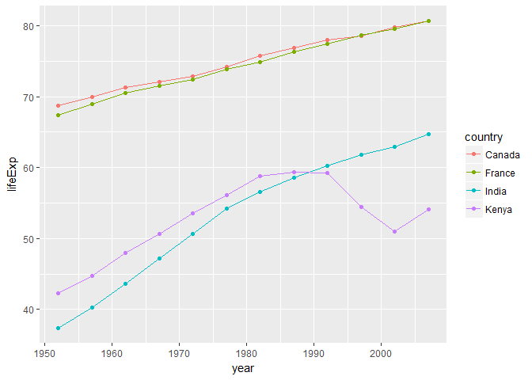

```r
##subsetting: looking at 4 countries
jCountries <- c("Canada", "Kenya", "France", "India")

ggplot(subset(gapminder, country %in% jCountries),
       aes(x = year, y = lifeExp, color= country)) + geom_line() +   geom_point()
```

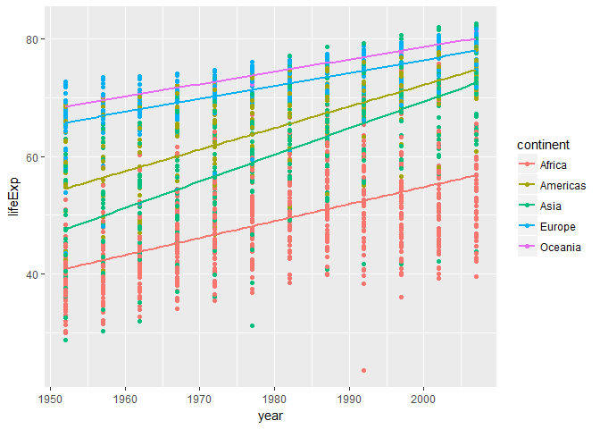

```r
#Make a plot of year (x) vs lifeExp (y), with points coloured by continent. Then, fit a regression line to each continent, without the error bars. If you can, try piping the data frame into the ggplot function
q <- ggplot(gapminder, aes(x=year, y=lifeExp, color=continent))

q + geom_point()+ geom_smooth(method=lm, se = FALSE)
```

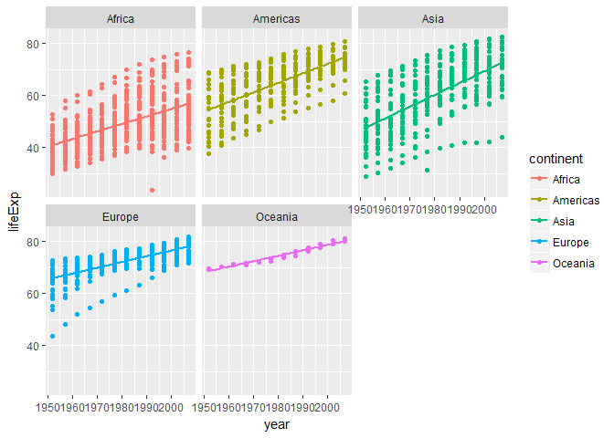

```r
##Make a plot of year (x) vs lifeExp (y), facetted by continent. Then, fit a smoother through the data for each continent, without the error bars. Choose a span that you feel is appropriate.
q + geom_point()+ geom_smooth(method=lm, se = FALSE) + facet_wrap(~continent)
```

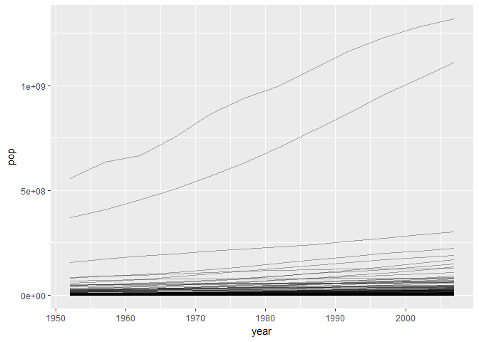

```r
##Plot the population over time (year) using lines, so that each country has its own line. Add alpha transparency to your liking.Add points to the plot in Exercise 7.
r <- ggplot(gapminder, aes(x=year, y=pop, group=country))
r + geom_line(alpha=1/3)
```

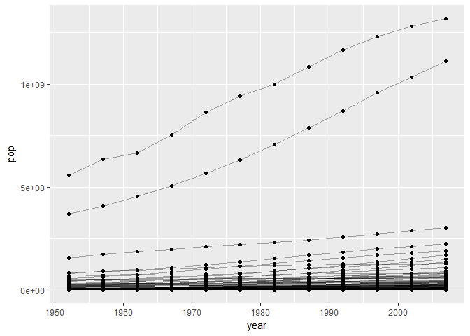

```r
r2 <-r + geom_line(alpha=1/3)
r2 + geom_point()
```

# Lecture 7

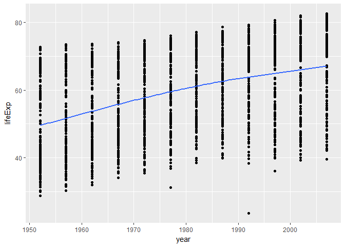

```r
# Regression curves
# Regression analysis fits some curve through the data, representing the mean of Y given the specified X value. Sometimes you assume a line (linear model) or can apply a general curve (i.e. a smoother)

vc1 <- ggplot(gapminder, aes(year, lifeExp)) +
    geom_point()
vc1 + geom_smooth(se=FALSE)
```

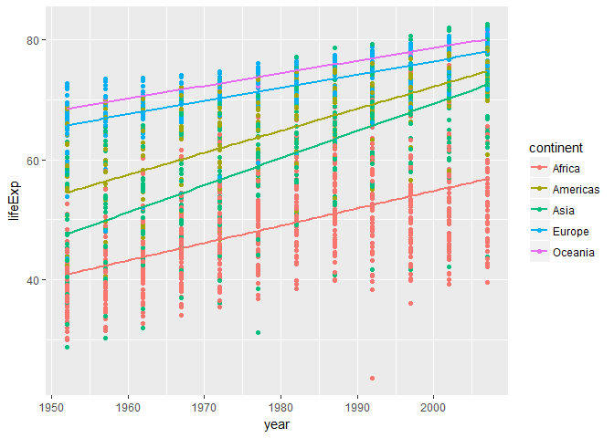

```r
# Exercise 1: Make a plot of year (x) vs lifeExp (y), with points coloured by continent. Then, to that same plot, fit a straight regression line to each continent, without the error bars. If you can, try piping the data frame into the ggplot function

ggplot(gapminder, aes(year, lifeExp, colour=continent)) +
  geom_point() +  # need this to show points on graph
  geom_smooth(method= "lm", se=FALSE)
```

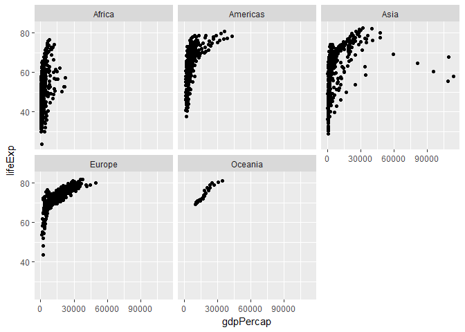

```r
# Facetting separates data from each group into its own “mini plot”, called a panel. These panels are arranged next to each otherfor easier comparison. There are two facetting functions in ggplot2: (1) facet_wrap: 1D facetting and (2) facet_grid: 2D facetting. Example of (1):

ggplot(gapminder, aes(gdpPercap, lifeExp)) +
    facet_wrap(~ continent) +
    geom_point()
```

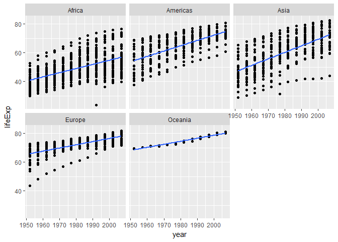

```r
# Exercise 2: Make a plot of year (x) vs lifeExp (y), facetted by continent. Then, fit a smoother through the data for each continent, without the error bars. Choose a span that you feel is appropriate. NOTE: A small span results in a more jagged curve; a larger one results in a smoother curve. You have to find one that fits your data

ggplot(gapminder, aes(year, lifeExp)) +
  geom_point() +
  facet_wrap(~continent)+
  geom_smooth(method = "lm", se=FALSE, span=1)
```

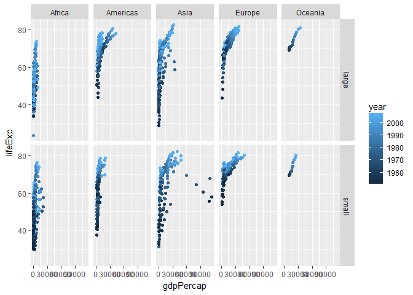

```r
# Facet_grid allows you to add a third variable so each row corresponds to one grouping and each column corresponds to another grouping. facet_grid(var 1~ var 2) Example 3: Look at continent and population size by “small” (<=7,000,000 population) and “large” (>7,000,000 population) countries.

vc2 <- gapminder %>%
    mutate(size=ifelse(pop > 7000000, "large", "small")) %>%     ggplot(aes(gdpPercap, lifeExp)) +
    facet_grid(size ~ continent)

vc2 + geom_point(aes(colour=year))
```

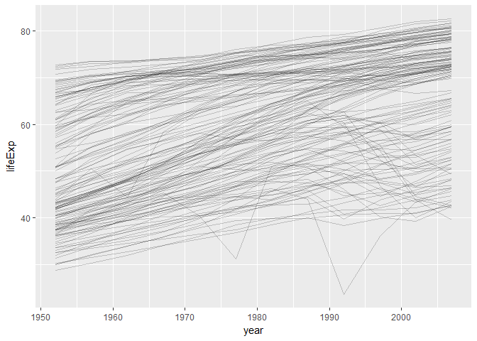

```r
# Connect the dots with geom_line (connect dots left-to-right) or geom_path (conects dots in the order they appear within the data frame). With these geoms, you must specify group=VARIABLE in your aesthetics (aes function), otherwise ggplot won’t distinguish between groups. Example:
ggplot(gapminder, aes(year, lifeExp, group=country)) +
    geom_line(alpha=0.2)
```

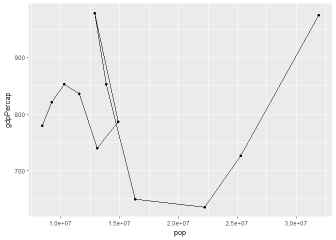

```r
# geom_path is typically used when a “time” variable is not shown on an axis. For example, let’s look at a scatterplot of pop vs. gdpPercap of Afghanistan, and let’s “connect the dots” in the order of time. Example:

gapminder %>%
    filter(country=="Afghanistan") %>%
    arrange(year) %>%
    ggplot(aes(pop, gdpPercap)) +
    geom_point() +
    geom_path()
```

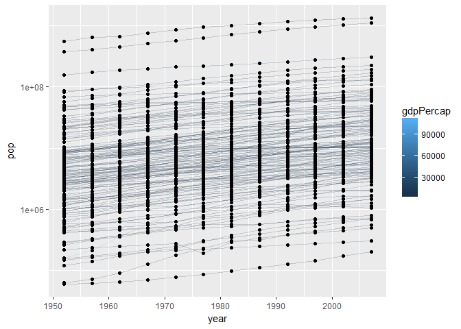

```r
# Example 4:  Plot the population over time (year) using lines, so that each country has its own line. Colour by  gdpPercap. Add alpha transparency to your liking. Fit it to a log 10 scale.

##remember group is essential for this!

ggplot(gapminder, aes(year, pop, group=country)) +
  geom_line(aes(colour=gdpPercap), alpha=0.2) +
  geom_point() +
  scale_y_log10()
```

# Lecture 8

## Modeling

First we will look at linear regression using the **lm()** function.

```r
# create a linear model
fit1 <- lm(lifeExp ~ log(gdpPercap), data=gapminder)
fit1
```

```
##
## Call:
## lm(formula = lifeExp ~ log(gdpPercap), data = gapminder)
##
## Coefficients:
##    (Intercept)  log(gdpPercap)
##         -9.101           8.405
```

```r
# can make predictions using the model. Remember if you don’t specify new data, it will make predictions using the existing X values.
predict(fit1) %>% head
```

```
##        1        2        3        4        5        6
## 46.86506 47.30012 47.62400 47.45579 46.42835 46.93666
```

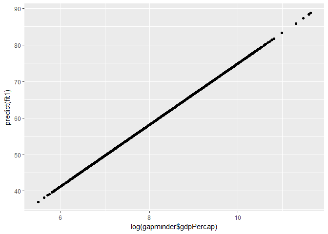

```r
# can plot again the original x values
qplot(log(gapminder$gdpPercap), predict(fit1))
```

```r
# can predict with new data as long as the data frame has the same column names as the x values.
(my_newdata <- data.frame(gdpPercap=c(100, 547, 289)))
```

```
##   gdpPercap
## 1       100
## 2       547
## 3       289
```

```r
predict(fit1, newdata=my_newdata)
```

```
##        1        2        3
## 29.60596 43.88854 38.52591
```

```r
predict(fit1, newdata=filter(gapminder, country=="Canada"))
```

```
##        1        2        3        4        5        6        7        8
## 69.38986 70.18158 70.81182 72.30336 73.69461 74.97451 75.27641 76.54409
##        9       10       11       12
## 76.45408 77.24871 78.43120 79.15337
```

```r
# can extract model characteristics
  #model coefficients
  coef(fit1)
```

```
##    (Intercept) log(gdpPercap)
##      -9.100889       8.405085
```

```r
  #residuals (looking at the first 6 and then plotting all)
  resid(fit1) %>% head
```

```
##          1          2          3          4          5          6
## -18.064063 -16.968123 -15.627000 -13.435788 -10.340352  -8.498661
```

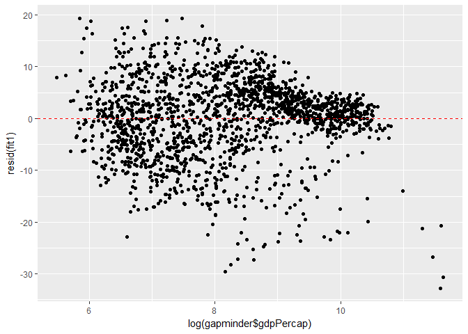

```r
  qplot(log(gapminder$gdpPercap), resid(fit1)) +
    geom_hline(yintercept=0, linetype="dashed", colour="red")
```

```r
  #lots of information can be determined using summary, such as p-values and standard errors
  summary(fit1)
```

```
##
## Call:
## lm(formula = lifeExp ~ log(gdpPercap), data = gapminder)
##
## Residuals:
##     Min      1Q  Median      3Q     Max
## -32.778  -4.204   1.212   4.658  19.285
##
## Coefficients:
##                Estimate Std. Error t value Pr(>|t|)
## (Intercept)     -9.1009     1.2277  -7.413 1.93e-13 ***
## log(gdpPercap)   8.4051     0.1488  56.500  < 2e-16 ***
## ---
## Signif. codes:  0 '***' 0.001 '**' 0.01 '*' 0.05 '.' 0.1 ' ' 1
##
## Residual standard error: 7.62 on 1702 degrees of freedom
## Multiple R-squared:  0.6522, Adjusted R-squared:  0.652
## F-statistic:  3192 on 1 and 1702 DF,  p-value: < 2.2e-16
```

```r
  #can extract specifics from the summary
  sum1 <- summary(fit1)

    #r-squared and r-square adjusted
    sum1$r.square
```

```
## [1] 0.6522466
```

```r
    sum1$adj.r.squared
```

```
## [1] 0.6520423
```

```r
    #estimated standard deviation of the random error term
    sum1$sigma
```

```
## [1] 7.619535
```

### Other Models:

1. generalized linear models (such as logistic regression). For this, you use the **glm()** function. It is quite similar to lm, except you need to specify what model to run using the family argument. Syntax includes:
   - Poisson regression: glm(y ~ x1 + x2 + … + xp, family=poisson, data=your_data_frame)
   - Logistic (aka Binomial) regression: glm(y ~ x1 + x2 + … + xp, family=binomial, data=your_data_frame)
2. Generalized) Mixed Effects Models: Two R packages are available: lme4 and nlme. Check out [this](https://stats.stackexchange.com/questions/5344/how-to-choose-nlme-or-lme4-r-library-for-mixed-effects-models) discussion for a comparison of the two packages.
3. Kernel smoothing (i.e. fitting a “smoother”): Check out the loess function.
4. Generalized Additive Models: The gam function in either the gam package or mgcv package.
5. Robust linear regression: The rlm function in the MASS package is your friend

## More dplyr

One of the most powerful functions is using **mutate()** with grouped tibble.

```r
# Exercise 1: Calculate the growth in population since the first year on record for each country
gapminder %>%
  group_by(country) %>%
  mutate(pop_growth = pop-pop[1])
```

```
## # A tibble: 1,704 x 7
## # Groups:   country [142]
##        country continent  year lifeExp      pop gdpPercap pop_growth
##         <fctr>    <fctr> <int>   <dbl>    <int>     <dbl>      <int>
##  1 Afghanistan      Asia  1952  28.801  8425333  779.4453          0
##  2 Afghanistan      Asia  1957  30.332  9240934  820.8530     815601
##  3 Afghanistan      Asia  1962  31.997 10267083  853.1007    1841750
##  4 Afghanistan      Asia  1967  34.020 11537966  836.1971    3112633
##  5 Afghanistan      Asia  1972  36.088 13079460  739.9811    4654127
##  6 Afghanistan      Asia  1977  38.438 14880372  786.1134    6455039
##  7 Afghanistan      Asia  1982  39.854 12881816  978.0114    4456483
##  8 Afghanistan      Asia  1987  40.822 13867957  852.3959    5442624
##  9 Afghanistan      Asia  1992  41.674 16317921  649.3414    7892588
## 10 Afghanistan      Asia  1997  41.763 22227415  635.3414   13802082
## # ... with 1,694 more rows
```

```r
# What about growth compared to 1972?
gapminder %>%
  group_by(country) %>%
  mutate(pop_growth = pop-pop[year==1972])
```

```
## # A tibble: 1,704 x 7
## # Groups:   country [142]
##        country continent  year lifeExp      pop gdpPercap pop_growth
##         <fctr>    <fctr> <int>   <dbl>    <int>     <dbl>      <int>
##  1 Afghanistan      Asia  1952  28.801  8425333  779.4453   -4654127
##  2 Afghanistan      Asia  1957  30.332  9240934  820.8530   -3838526
##  3 Afghanistan      Asia  1962  31.997 10267083  853.1007   -2812377
##  4 Afghanistan      Asia  1967  34.020 11537966  836.1971   -1541494
##  5 Afghanistan      Asia  1972  36.088 13079460  739.9811          0
##  6 Afghanistan      Asia  1977  38.438 14880372  786.1134    1800912
##  7 Afghanistan      Asia  1982  39.854 12881816  978.0114    -197644
##  8 Afghanistan      Asia  1987  40.822 13867957  852.3959     788497
##  9 Afghanistan      Asia  1992  41.674 16317921  649.3414    3238461
## 10 Afghanistan      Asia  1997  41.763 22227415  635.3414    9147955
## # ... with 1,694 more rows
```

- Vectorized Functions: These take a vector, and operate on each component independently to return a vector of the same length. In other words, they work element-wise.
  - Examples are cos, sin, log, exp, round.
  - We don’t need to group_by in order to mutate with these.

*Aggregate Functions: These take a vector, and return a vector of length 1 – as if “aggregating” the values in the vector into a single value.* Examples are mean, sd, length, typeof. * We use these in dplyr’s summarise function.

- Window Functions: these take a vector, and return a vector of the same length that depends on other values in the vector.
  - Examples are lag, rank, cumsum.
  - See the window-functions vignette for the dplyr package.

## More ggplot

- The [ggplot2 cheatsheet](https://www.rstudio.com/wp-content/uploads/2015/03/ggplot2-cheatsheet.pdf) is very helpful for data visualization.
1. Themes You can change the look of the plot (e.g. font, justification of title, line thickness) using existing themes. There are complete themes already created, which you can see [here](http://ggplot2.tidyverse.org/reference/ggtheme.html).

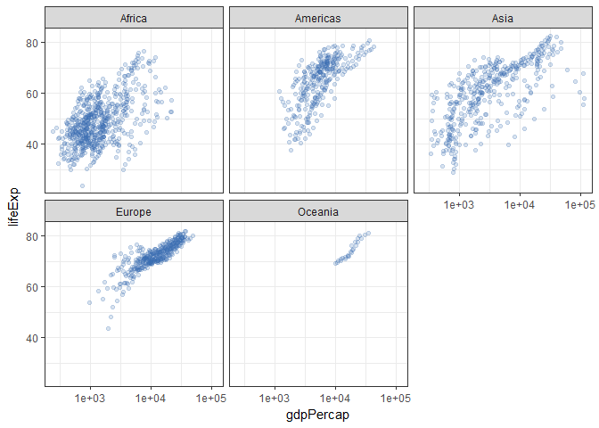

```r
# An example of using the theme_bw theme
p1 <- ggplot(gapminder, aes(gdpPercap, lifeExp)) +
    facet_wrap(~ continent) +
    geom_point(colour="#386CB0", alpha=0.2) +
    scale_x_log10()
p1 + theme_bw()
```

You can modify theme elements by selecting an argument name (e.g. axis.title, strip.text) and then specifying the value using one of these functions: * element_blank: leave things as is * element_rect: change features of a rectangle * element_line: change features of a line * element_text: change fonts

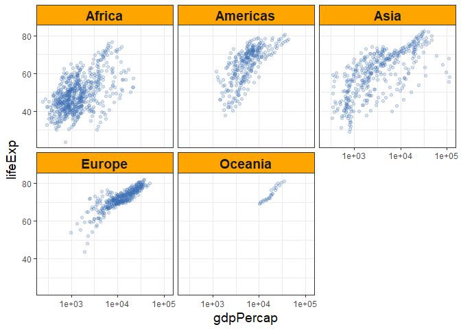

```r
# For example, change the strip background to orange as well as increase font size to 14 and bold panel titles
p1 +
  theme_bw() +  # before modifications or overrides changes
    theme(strip.background = element_rect(fill="orange"),
          axis.title = element_text(size=14),
          strip.text = element_text(size=14, face="bold"))
```

2. Modifying scales Scales control the mapping from data to aesthetics. They take your data and turn it into something that you can see, like size, colour, position or shape. Scales also provide the tools that let you read the plot: the axes and legends. Formally, each scale is a function from a region in data space (the domain of the scale) to a region in aesthetic space (the range of the scale). Go [here](https://github.com/hadley/ggplot2-book/blob/master/scales.rmd) for a lesson.

We can modify scales using a suite of functions that have the following naming convention: scale_a_b, where: * a is the scale you want to change (e.g. colour, size). * b typically speaks to the nature of the variable (e.g. continuous, discrete, log10). * Examples: scale_x_continuous, scale_colour_discrete, scale_y_sqrt. * These are added as layers

**Useful Arguments** 1. name: The first argument. Indicate the name of the scale/legend here. Can also use labs().

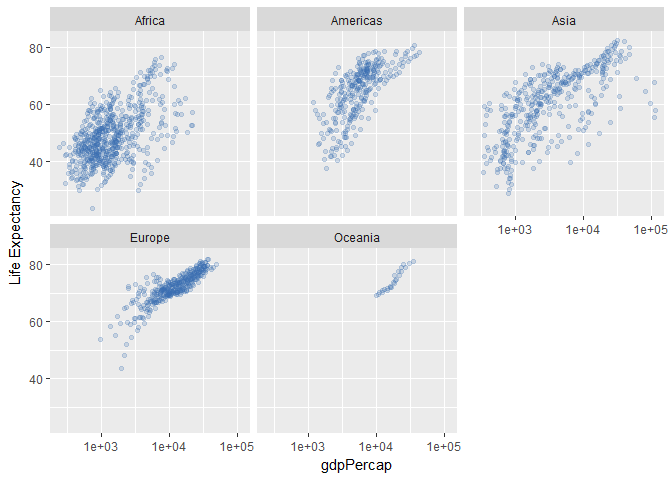

```r
# Examples
p1 + scale_y_continuous("Life Expectancy")
```

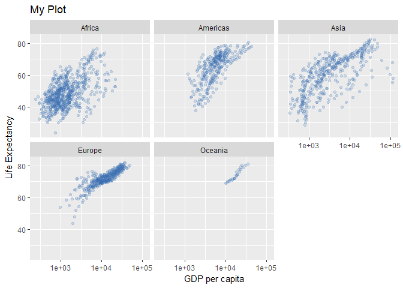

```r
p1 + labs(x="GDP per capita",
          y="Life Expectancy",
          title="My Plot")
```

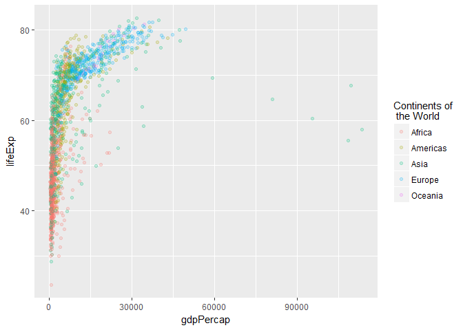

```r
ggplot(gapminder, aes(gdpPercap, lifeExp)) +
    geom_point(aes(colour=continent),
               alpha=0.2) +
    scale_colour_discrete("Continents of\n the World")
```

2. breaks: you get to specify where along the scale you’d like to display a value for continuous data. Numbers are on the scale of the data (such as population).

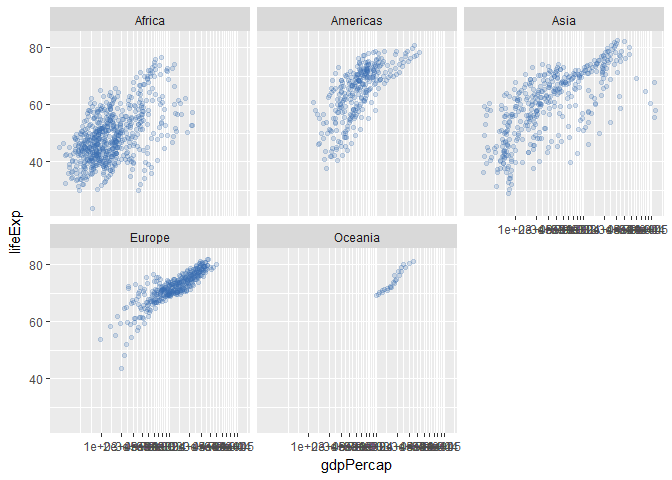

```r
# Example
## Log lines:
p1 + scale_x_log10(breaks=c((1:10)*1000,
                            (1:10)*10000))
```

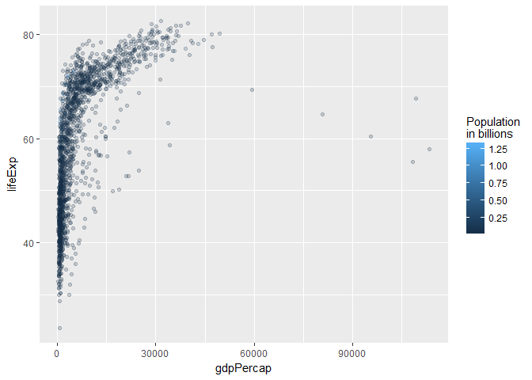

```r
p2 <- ggplot(gapminder, aes(gdpPercap, lifeExp)) +
    geom_point(aes(colour=pop/10^9),
               alpha=0.2)

## Default breaks
p2 + scale_colour_continuous("Population\nin billions")
```

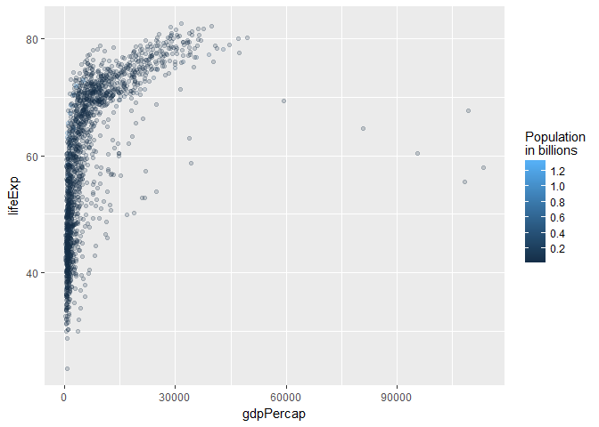

```r
## New breaks
p2 + scale_colour_continuous("Population\nin billions",
                             breaks=seq(0,2,by=0.2))
```

3. Labels Text to replace the data value labels. Most useful for discrete data.

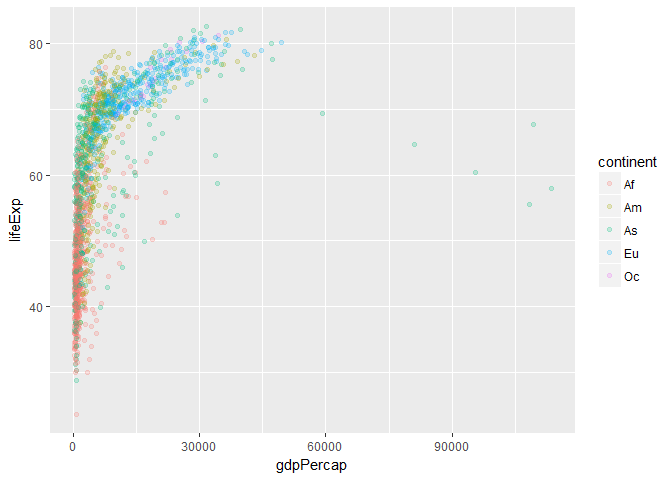

```r
# Example
ggplot(gapminder, aes(gdpPercap, lifeExp)) +
    geom_point(aes(colour=continent), alpha=0.2) +
    scale_colour_discrete(labels=c("Af", "Am", "As", "Eu", "Oc"))
```

4. Limits Lower and upper bounds of the data that you’d like displayed. Leave one as NA if you want to use the default.

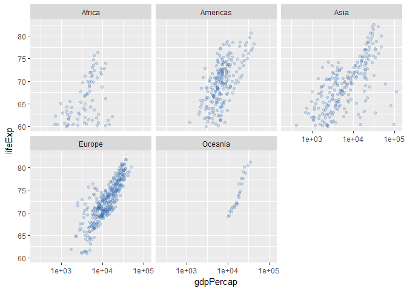

```r
p1 + scale_y_continuous(limits=c(60,NA))
```

5. Position Position of the scale. Also controllable using theme for the legend.

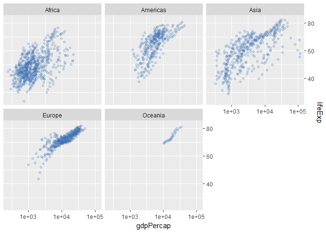

```r
p1 + scale_y_continuous(position="right")
```

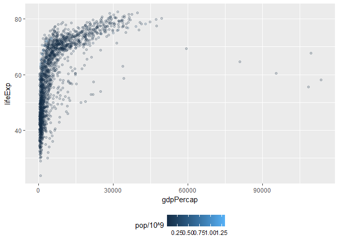

```r
p2 + theme(legend.position = "bottom")
```

## Exercises

Practice what was learned above.

1. Suppose we want to calculate some quantity for each country in the gapminder data set. For each of the following quantities, indicate whether the function is vectorized, aggregate, or window, and use dplyr functions to calculate the specified variable.
   1. The change in population from 1962 to 1972.

```r
## aggregrate
gapminder %>%
  group_by(country) %>%
  summarize(pop_change = pop[year==1972]-pop[year==1962])
```

```
## # A tibble: 142 x 2
##        country pop_change
##         <fctr>      <int>
##  1 Afghanistan    2812377
##  2     Albania     535417
##  3     Algeria    3759839
##  4      Angola    1068843
##  5   Argentina    3496016
##  6   Australia    2382032
##  7     Austria     414337
##  8     Bahrain      58937
##  9  Bangladesh   13920006
## 10     Belgium     490700
## # ... with 132 more rows
```

```
b) Population in Billions
```

```r
## vectorize
gapminder %>%
  group_by(country) %>%
  mutate(pop_billion = pop/10^9)
```

```
## # A tibble: 1,704 x 7
## # Groups:   country [142]
##        country continent  year lifeExp      pop gdpPercap pop_billion
##         <fctr>    <fctr> <int>   <dbl>    <int>     <dbl>       <dbl>
##  1 Afghanistan      Asia  1952  28.801  8425333  779.4453 0.008425333
##  2 Afghanistan      Asia  1957  30.332  9240934  820.8530 0.009240934
##  3 Afghanistan      Asia  1962  31.997 10267083  853.1007 0.010267083
##  4 Afghanistan      Asia  1967  34.020 11537966  836.1971 0.011537966
##  5 Afghanistan      Asia  1972  36.088 13079460  739.9811 0.013079460
##  6 Afghanistan      Asia  1977  38.438 14880372  786.1134 0.014880372
##  7 Afghanistan      Asia  1982  39.854 12881816  978.0114 0.012881816
##  8 Afghanistan      Asia  1987  40.822 13867957  852.3959 0.013867957
##  9 Afghanistan      Asia  1992  41.674 16317921  649.3414 0.016317921
## 10 Afghanistan      Asia  1997  41.763 22227415  635.3414 0.022227415
## # ... with 1,694 more rows
```

```
c) Lagged gdpPercap
```

```r
## window
gapminder %>%
    group_by(country) %>%
    arrange(year) %>%
    mutate(lag_gdpPercap=lag(gdpPercap)) %>%
    filter(!is.na(lag_gdpPercap))
```

```
## # A tibble: 1,562 x 7
## # Groups:   country [142]
##        country continent  year lifeExp      pop  gdpPercap lag_gdpPercap
##         <fctr>    <fctr> <int>   <dbl>    <int>      <dbl>         <dbl>
##  1 Afghanistan      Asia  1957  30.332  9240934   820.8530      779.4453
##  2     Albania    Europe  1957  59.280  1476505  1942.2842     1601.0561
##  3     Algeria    Africa  1957  45.685 10270856  3013.9760     2449.0082
##  4      Angola    Africa  1957  31.999  4561361  3827.9405     3520.6103
##  5   Argentina  Americas  1957  64.399 19610538  6856.8562     5911.3151
##  6   Australia   Oceania  1957  70.330  9712569 10949.6496    10039.5956
##  7     Austria    Europe  1957  67.480  6965860  8842.5980     6137.0765
##  8     Bahrain      Asia  1957  53.832   138655 11635.7995     9867.0848
##  9  Bangladesh      Asia  1957  39.348 51365468   661.6375      684.2442
## 10     Belgium    Europe  1957  69.240  8989111  9714.9606     8343.1051
## # ... with 1,552 more rows
```

2. For the gapminder dataset, make a spaghetti plot showing the population trend (in millions) over time for each country, facetted by continent. Make as many of the following modifications as you can:

*Colour each line by the log maximum gdpPercap experienced by the country.* Rotate the x-axis labels to be vertical. *Remove the x-axis title.* Give the legend an appropriate title. *Put the y-axis on a log-scale.* Rename the y-axis title. *Add more numbers along the y-axis.* Give the plot a title, and center the title. *Only label the x axis with years 1950, 1975, and 2000.* Move the colour scale to the bottom. *Rename the colour legend

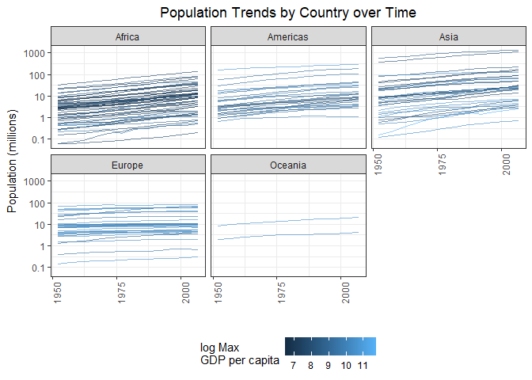

```r
gapminder %>%
  group_by(country) %>%
  mutate(pop_mill = pop/10^6, max_gdpPercap = max(gdpPercap)) %>%
  ggplot(aes(year, pop_mill)) +
    facet_wrap(~ continent) +
    geom_line(aes(group=country, colour=log(max_gdpPercap)), alpha=0.6) +
  theme_bw() +
  labs(title="Population Trends by Country over Time") +
  scale_y_log10( "Population (millions)",
                 breaks=c(0.1, 1, 10, 100, 1000),
                labels=c(0.1, 1, 10, 100, 1000)) +
  scale_x_continuous("", breaks=c(1950, 1975, 2000)) +
  scale_colour_continuous("log Max\nGDP per capita") +
  theme(axis.text.x = element_text(angle=90),
          plot.title = element_text(hjust=0.5),
          legend.position = "bottom")
```

# Lecture 9

It’s rare that a data analysis involves only a single table of data. In practice, you’ll normally have many tables that contribute to an analysis, and you need flexible tools to combine them. In dplyr, there are three families of verbs that work with two tables at a time (see below). All work similarly: the first two arguments are x and y, and provide the tables to combine. The output is always a new table with the same type as x.

1. **Mutating Joins**, which add new variables to one table from matching rows in another.

```r
#load library
library("nycflights13")
  #data saved as seveeral data sets automatically: flights, airlines, planes, weather

##Basic Join:
# Drop unimportant variables so it's easier to understand the join results.
flights2 <- flights %>% select(year:day, hour, origin, dest, tailnum, carrier)

#join by carrier
flights2 %>%
  left_join(airlines)
```

```
## # A tibble: 336,776 x 9
##     year month   day  hour origin  dest tailnum carrier
##    <int> <int> <int> <dbl>  <chr> <chr>   <chr>   <chr>
##  1  2013     1     1     5    EWR   IAH  N14228      UA
##  2  2013     1     1     5    LGA   IAH  N24211      UA
##  3  2013     1     1     5    JFK   MIA  N619AA      AA
##  4  2013     1     1     5    JFK   BQN  N804JB      B6
##  5  2013     1     1     6    LGA   ATL  N668DN      DL
##  6  2013     1     1     5    EWR   ORD  N39463      UA
##  7  2013     1     1     6    EWR   FLL  N516JB      B6
##  8  2013     1     1     6    LGA   IAD  N829AS      EV
##  9  2013     1     1     6    JFK   MCO  N593JB      B6
## 10  2013     1     1     6    LGA   ORD  N3ALAA      AA
## # ... with 336,766 more rows, and 1 more variables: name <chr>
```

Each mutating join takes an argument **by** that controls which variables are used to match observations in the two tables. There are a few ways to specify it: * by=NULL, dplyr will will use all variables that appear in both tables, a natural join.

```r
# the flights and weather tables match on their common variables: year, month, day, hour and origin
flights2 %>% left_join(weather)
```

```
## # A tibble: 336,776 x 18
##     year month   day  hour origin  dest tailnum carrier  temp  dewp humid
##    <dbl> <dbl> <int> <dbl>  <chr> <chr>   <chr>   <chr> <dbl> <dbl> <dbl>
##  1  2013     1     1     5    EWR   IAH  N14228      UA    NA    NA    NA
##  2  2013     1     1     5    LGA   IAH  N24211      UA    NA    NA    NA
##  3  2013     1     1     5    JFK   MIA  N619AA      AA    NA    NA    NA
##  4  2013     1     1     5    JFK   BQN  N804JB      B6    NA    NA    NA
##  5  2013     1     1     6    LGA   ATL  N668DN      DL 39.92 26.06 57.33
##  6  2013     1     1     5    EWR   ORD  N39463      UA    NA    NA    NA
##  7  2013     1     1     6    EWR   FLL  N516JB      B6 39.02 26.06 59.37
##  8  2013     1     1     6    LGA   IAD  N829AS      EV 39.92 26.06 57.33
##  9  2013     1     1     6    JFK   MCO  N593JB      B6 39.02 26.06 59.37
## 10  2013     1     1     6    LGA   ORD  N3ALAA      AA 39.92 26.06 57.33
## # ... with 336,766 more rows, and 7 more variables: wind_dir <dbl>,
## #   wind_speed <dbl>, wind_gust <dbl>, precip <dbl>, pressure <dbl>,
## #   visib <dbl>, time_hour <dttm>
```

- by=“x”, join is controlled by a character vector

```r
# flights and planes have year columns, but they mean different things so we only want to join by tailnum.
flights2 %>% left_join(planes, by = "tailnum")
```

```
## # A tibble: 336,776 x 16
##    year.x month   day  hour origin  dest tailnum carrier year.y
##     <int> <int> <int> <dbl>  <chr> <chr>   <chr>   <chr>  <int>
##  1   2013     1     1     5    EWR   IAH  N14228      UA   1999
##  2   2013     1     1     5    LGA   IAH  N24211      UA   1998
##  3   2013     1     1     5    JFK   MIA  N619AA      AA   1990
##  4   2013     1     1     5    JFK   BQN  N804JB      B6   2012
##  5   2013     1     1     6    LGA   ATL  N668DN      DL   1991
##  6   2013     1     1     5    EWR   ORD  N39463      UA   2012
##  7   2013     1     1     6    EWR   FLL  N516JB      B6   2000
##  8   2013     1     1     6    LGA   IAD  N829AS      EV   1998
##  9   2013     1     1     6    JFK   MCO  N593JB      B6   2004
## 10   2013     1     1     6    LGA   ORD  N3ALAA      AA     NA
## # ... with 336,766 more rows, and 7 more variables: type <chr>,
## #   manufacturer <chr>, model <chr>, engines <int>, seats <int>,
## #   speed <int>, engine <chr>
```

- by = c(“x” = “a”), join is controlled by a named character vector. This will match variable *x* in table x to variable *a* in table a. The variables from use will be used in the output.

```r
# Each flight has an origin and destination airport, so we need to specify which one we want to join to
flights2 %>% left_join(airports, c("dest" = "faa"))
```

```
## # A tibble: 336,776 x 15
##     year month   day  hour origin  dest tailnum carrier
##    <int> <int> <int> <dbl>  <chr> <chr>   <chr>   <chr>
##  1  2013     1     1     5    EWR   IAH  N14228      UA
##  2  2013     1     1     5    LGA   IAH  N24211      UA
##  3  2013     1     1     5    JFK   MIA  N619AA      AA
##  4  2013     1     1     5    JFK   BQN  N804JB      B6
##  5  2013     1     1     6    LGA   ATL  N668DN      DL
##  6  2013     1     1     5    EWR   ORD  N39463      UA
##  7  2013     1     1     6    EWR   FLL  N516JB      B6
##  8  2013     1     1     6    LGA   IAD  N829AS      EV
##  9  2013     1     1     6    JFK   MCO  N593JB      B6
## 10  2013     1     1     6    LGA   ORD  N3ALAA      AA
## # ... with 336,766 more rows, and 7 more variables: name <chr>, lat <dbl>,
## #   lon <dbl>, alt <int>, tz <dbl>, dst <chr>, tzone <chr>
```

```r
flights2 %>% left_join(airports, c("origin" = "faa"))
```

```
## # A tibble: 336,776 x 15
##     year month   day  hour origin  dest tailnum carrier
##    <int> <int> <int> <dbl>  <chr> <chr>   <chr>   <chr>
##  1  2013     1     1     5    EWR   IAH  N14228      UA
##  2  2013     1     1     5    LGA   IAH  N24211      UA
##  3  2013     1     1     5    JFK   MIA  N619AA      AA
##  4  2013     1     1     5    JFK   BQN  N804JB      B6
##  5  2013     1     1     6    LGA   ATL  N668DN      DL
##  6  2013     1     1     5    EWR   ORD  N39463      UA
##  7  2013     1     1     6    EWR   FLL  N516JB      B6
##  8  2013     1     1     6    LGA   IAD  N829AS      EV
##  9  2013     1     1     6    JFK   MCO  N593JB      B6
## 10  2013     1     1     6    LGA   ORD  N3ALAA      AA
## # ... with 336,766 more rows, and 7 more variables: name <chr>, lat <dbl>,
## #   lon <dbl>, alt <int>, tz <dbl>, dst <chr>, tzone <chr>
```

### Types of Mutating Joins

```r
#create two test data frames to illustrate types
(df1 <- data_frame(x = c(1, 2), y = 2:1))
```

```
## # A tibble: 2 x 2
##       x     y
##   <dbl> <int>
## 1     1     2
## 2     2     1
```

```r
(df2 <- data_frame(x = c(1, 3), a = 10, b = "a"))
```

```
## # A tibble: 2 x 3
##       x     a     b
##   <dbl> <dbl> <chr>
## 1     1    10     a
## 2     3    10     a
```

1. **inner_join(x,y)** only includes observations that match in both x and y.

```r
# joining, by = "x"
df1 %>% inner_join(df2)
```

```
## # A tibble: 1 x 4
##       x     y     a     b
##   <dbl> <int> <dbl> <chr>
## 1     1     2    10     a
```

2. **left_join(x,y)** includes all observations in *x*, regardless of whether they match or not. This is the most commonly used join because it ensures that you don’t lose observations from your primary table.

```r
# joining, by = "x"
df1 %>% left_join(df2)
```

```
## # A tibble: 2 x 4
##       x     y     a     b
##   <dbl> <int> <dbl> <chr>
## 1     1     2    10     a
## 2     2     1    NA  <NA>
```

3. **right_join(x, y)** includes all observations in y. It’s equivalent to left_join(y, x), but the columns will be ordered differently.

```r
df1 %>% right_join(df2)
```

```
## # A tibble: 2 x 4
##       x     y     a     b
##   <dbl> <int> <dbl> <chr>
## 1     1     2    10     a
## 2     3    NA    10     a
```

4. **full_join()** includes all observations from x and y.

```r
df1 %>% full_join(df2)
```

```
## # A tibble: 3 x 4
##       x     y     a     b
##   <dbl> <int> <dbl> <chr>
## 1     1     2    10     a
## 2     2     1    NA  <NA>
## 3     3    NA    10     a
```

**NOTE:**The left, right and full joins are collectively know as **outer joins**. When a row doesn’t match in an outer join, the new variables are filled in with missing values.

2. **Filtering joins**, which filter observations from one table based on whether or not they match an observation in the other table. Filtering joins match obserations in the same way as mutating joins, but affect the observations, not the variables. There are two types:
1. **semi_join(x, y)** keeps all observations in x that have a match in y.
2. **anti_join(x, y)** drops all observations in x that have a match in y

These are most useful for diagnosing join mismatches:

```r
# there are many flights in the nycflights13 dataset that don’t have a matching tail number in the planes table
flights %>%
  anti_join(planes, by = "tailnum") %>%
  count(tailnum, sort = TRUE)
```

```
## # A tibble: 722 x 2
##    tailnum     n
##      <chr> <int>
##  1    <NA>  2512
##  2  N725MQ   575
##  3  N722MQ   513
##  4  N723MQ   507
##  5  N713MQ   483
##  6  N735MQ   396
##  7  N0EGMQ   371
##  8  N534MQ   364
##  9  N542MQ   363
## 10  N531MQ   349
## # ... with 712 more rows
```

3. **Set operations** combine the observations in the data sets as if they were set elements. These expect the x and y inputs to have the same variables, and treat the observations like sets:
   - **intersect(x, y)**: return only observations in both x and y
   - **union(x, y)**: return unique observations in x and y
   - **setdiff(x, y)**: return observations in x, but not in y.

```r
#create two simple datasets to test
(df1 <- data_frame(x = 1:2, y = c(1L, 1L)))
```

```
## # A tibble: 2 x 2
##       x     y
##   <int> <int>
## 1     1     1
## 2     2     1
```

```r
(df2 <- data_frame(x = 1:2, y = 1:2))
```

```
## # A tibble: 2 x 2
##       x     y
##   <int> <int>
## 1     1     1
## 2     2     2
```

```r
#only keeps one observation
intersect(df1, df2)
```

```
## # A tibble: 1 x 2
##       x     y
##   <int> <int>
## 1     1     1
```

```r
#has three observations (1 shared between two data sets, 1 unique observation from df1, 1 unique observation fom df2)
union(df1, df2)
```

```
## # A tibble: 3 x 2
##       x     y
##   <int> <int>
## 1     1     1
## 2     2     1
## 3     2     2
```

```r
#only 1 observation (1 unique from df1)
setdiff(df1, df2)
```

```
## # A tibble: 1 x 2
##       x     y
##   <int> <int>
## 1     2     1
```

```r
#only 1 observation (1 unique from df2)
setdiff(df2, df1)
```

```
## # A tibble: 1 x 2
##       x     y
##   <int> <int>
## 1     2     2
```

### Coercion Rules

When joining tables, dplyr is a little more conservative than base R about the types of variable that it considers equivalent. This is mostly likely to surprise if you’re working factors: * Factors with different levels are coerced to character * Factors with the same levels in a different order are coerced to character * Factors are preserved only if the levels match exactly * Factor and a character are coerced to character

## Exercises:

```r
#Consider the following areas of countries, in hectares:
(areas <- data.frame(country=c("Canada", "United States", "India", "Vatican City"), area=c(998.5*10^6, 983.4*10^6, 328.7*10^6, 44)) %>%
     as.tbl)
```

```
## # A tibble: 4 x 2
##         country      area
##          <fctr>     <dbl>
## 1        Canada 998500000
## 2 United States 983400000
## 3         India 328700000
## 4  Vatican City        44
```

1. To the gapminder dataset, add an area variable using the areas tibble. Be sure to preserve all the rows of the original gapminder dataset.

```r
left_join(gapminder, areas)
```

```
## # A tibble: 1,704 x 7
##        country continent  year lifeExp      pop gdpPercap  area
##          <chr>    <fctr> <int>   <dbl>    <int>     <dbl> <dbl>
##  1 Afghanistan      Asia  1952  28.801  8425333  779.4453    NA
##  2 Afghanistan      Asia  1957  30.332  9240934  820.8530    NA
##  3 Afghanistan      Asia  1962  31.997 10267083  853.1007    NA
##  4 Afghanistan      Asia  1967  34.020 11537966  836.1971    NA
##  5 Afghanistan      Asia  1972  36.088 13079460  739.9811    NA
##  6 Afghanistan      Asia  1977  38.438 14880372  786.1134    NA
##  7 Afghanistan      Asia  1982  39.854 12881816  978.0114    NA
##  8 Afghanistan      Asia  1987  40.822 13867957  852.3959    NA
##  9 Afghanistan      Asia  1992  41.674 16317921  649.3414    NA
## 10 Afghanistan      Asia  1997  41.763 22227415  635.3414    NA
## # ... with 1,694 more rows
```

2. To the gapminder dataset, add an area variable using the areas tibble, but only keeping obervations for which areas are available

```r
inner_join(gapminder, areas)
```

```
## # A tibble: 36 x 7
##    country continent  year lifeExp      pop gdpPercap      area
##      <chr>    <fctr> <int>   <dbl>    <int>     <dbl>     <dbl>
##  1  Canada  Americas  1952   68.75 14785584  11367.16 998500000
##  2  Canada  Americas  1957   69.96 17010154  12489.95 998500000
##  3  Canada  Americas  1962   71.30 18985849  13462.49 998500000
##  4  Canada  Americas  1967   72.13 20819767  16076.59 998500000
##  5  Canada  Americas  1972   72.88 22284500  18970.57 998500000
##  6  Canada  Americas  1977   74.21 23796400  22090.88 998500000
##  7  Canada  Americas  1982   75.76 25201900  22898.79 998500000
##  8  Canada  Americas  1987   76.86 26549700  26626.52 998500000
##  9  Canada  Americas  1992   77.95 28523502  26342.88 998500000
## 10  Canada  Americas  1997   78.61 30305843  28954.93 998500000
## # ... with 26 more rows
```

3. Use a _join function to output the rows in areas corresponding to countries that are not found in the gapminder dataset.

```r
anti_join(areas, gapminder)
```

```
## # A tibble: 1 x 2
##        country  area
##         <fctr> <dbl>
## 1 Vatican City    44
```

4. Use a _join function to output the rows in areas corresponding to countries that are found in the gapminder dataset.

```r
semi_join(areas, gapminder, by="country")
```

```
## # A tibble: 3 x 2
##         country      area
##          <fctr>     <dbl>
## 1        Canada 998500000
## 2 United States 983400000
## 3         India 328700000
```

5. Construct a tibble that joins gapminder and areas, so that all rows found in each original tibble are also found in the final tibble.

```r
full_join(areas, gapminder, by="country")
```

```
## # A tibble: 1,705 x 7
##    country      area continent  year lifeExp      pop gdpPercap
##      <chr>     <dbl>    <fctr> <int>   <dbl>    <int>     <dbl>
##  1  Canada 998500000  Americas  1952   68.75 14785584  11367.16
##  2  Canada 998500000  Americas  1957   69.96 17010154  12489.95
##  3  Canada 998500000  Americas  1962   71.30 18985849  13462.49
##  4  Canada 998500000  Americas  1967   72.13 20819767  16076.59
##  5  Canada 998500000  Americas  1972   72.88 22284500  18970.57
##  6  Canada 998500000  Americas  1977   74.21 23796400  22090.88
##  7  Canada 998500000  Americas  1982   75.76 25201900  22898.79
##  8  Canada 998500000  Americas  1987   76.86 26549700  26626.52
##  9  Canada 998500000  Americas  1992   77.95 28523502  26342.88
## 10  Canada 998500000  Americas  1997   78.61 30305843  28954.93
## # ... with 1,695 more rows
```

6. Subset the gapminder dataset to have countries that are only found in the areas data frame.

```r
semi_join(gapminder, areas)
```

```
## # A tibble: 36 x 6
##    country continent  year lifeExp      pop gdpPercap
##     <fctr>    <fctr> <int>   <dbl>    <int>     <dbl>
##  1  Canada  Americas  1952   68.75 14785584  11367.16
##  2  Canada  Americas  1957   69.96 17010154  12489.95
##  3  Canada  Americas  1962   71.30 18985849  13462.49
##  4  Canada  Americas  1967   72.13 20819767  16076.59
##  5  Canada  Americas  1972   72.88 22284500  18970.57
##  6  Canada  Americas  1977   74.21 23796400  22090.88
##  7  Canada  Americas  1982   75.76 25201900  22898.79
##  8  Canada  Americas  1987   76.86 26549700  26626.52
##  9  Canada  Americas  1992   77.95 28523502  26342.88
## 10  Canada  Americas  1997   78.61 30305843  28954.93
## # ... with 26 more rows
```

7. Subset the gapminder dataset to have countries that are not found in the areas data frame.

```r
anti_join(gapminder, areas)
```

```
## # A tibble: 1,668 x 6
##        country continent  year lifeExp      pop gdpPercap
##         <fctr>    <fctr> <int>   <dbl>    <int>     <dbl>
##  1 Afghanistan      Asia  1952  28.801  8425333  779.4453
##  2 Afghanistan      Asia  1957  30.332  9240934  820.8530
##  3 Afghanistan      Asia  1962  31.997 10267083  853.1007
##  4 Afghanistan      Asia  1967  34.020 11537966  836.1971
##  5 Afghanistan      Asia  1972  36.088 13079460  739.9811
##  6 Afghanistan      Asia  1977  38.438 14880372  786.1134
##  7 Afghanistan      Asia  1982  39.854 12881816  978.0114
##  8 Afghanistan      Asia  1987  40.822 13867957  852.3959
##  9 Afghanistan      Asia  1992  41.674 16317921  649.3414
## 10 Afghanistan      Asia  1997  41.763 22227415  635.3414
## # ... with 1,658 more rows
```

**NOTE:** A [helpful cheatsheet](http://stat545.com/bit001_dplyr-cheatsheet.html) has been created for dplyr join functions.

# Lecture 10

# Lecture 11

```r
#install data set and libraries
devtools::install_github("JoeyBernhardt/singer")
library(singer)
library(tidyverse)
library(reshape2)
```

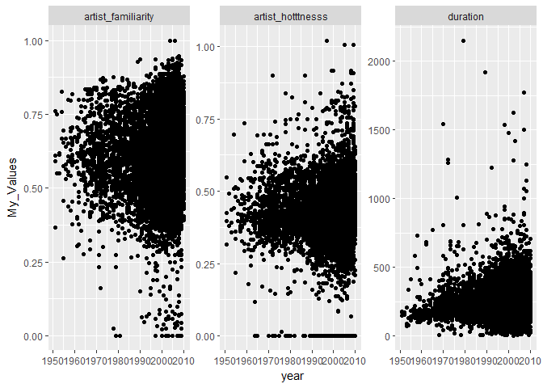

```r
# Task 1
## move from wide format to narrow
data("singer_locations")

hfd_y <-singer_locations %>%
  select(year, duration:artist_familiarity) %>%
  gather(key= "Measures", value = "My_Values",
    duration:artist_familiarity)

## graph the above in a meaningful way
hfd_y %>%
  filter(year > 1950) %>%
  ggplot(aes(x = year, y = My_Values)) +
  geom_point() +
  facet_wrap(~Measures, scales = "free_y")  #free_y = allows y scales to match data for each graph in facet
```

```r
# Task 2: Add unique identifer and move back to wide format
hfd_y2 <-singer_locations %>%
  select(song_id, year, duration:artist_familiarity) %>%
  gather(key= "Measures", value = "My_Values",
    duration:artist_familiarity)

hfd_y2 %>%
  spread(Measures, My_Values) #spread only works when each row has it's own unique ID
```

```
## # A tibble: 10,100 x 5
##               song_id  year artist_familiarity artist_hotttnesss duration
##  *              <chr> <int>              <dbl>             <dbl>    <dbl>
##  1 SOAACEN12A8C13AC90  2005         0.77531968         0.4823410 357.1718
##  2 SOAAEOE12A67021AA2  2002         0.58969461         0.3838637 212.8453
##  3 SOAAEUS12AB0184906  1990         0.44743723         0.4266528 243.4869
##  4 SOAAHHZ12AB0181950  2005         0.05807275         0.0000000 253.8314
##  5 SOAAIJG12AAA15D821  2008         0.72233073         0.4859998 399.7514
##  6 SOAAMSA12AB0185275  2008         0.62352595         0.4373072 208.2216
##  7 SOAAPDT12A6D4F9957  2002         0.50247255         0.3420969 276.7408
##  8 SOAAQSY12A58A7CBFF  1990         0.52227232         0.3660433 219.7416
##  9 SOAARXN12D021B0F39  2007         0.82290110         0.5756396 298.9710
## 10 SOAASND12A58A7A70B  2001         0.64758740         0.4309697 226.2200
## # ... with 10,090 more rows
```

```r
# Task 3: Use Reshape 2 when do not have a unique ID or when you want to aggregate some rows
hfd_y %>%
  dcast(year ~ Measures, value.var = "My_Values", fun.aggregate = mean, na.rm = TRUE)
```

```
##    year artist_familiarity artist_hotttnesss duration
## 1     0          0.5052371         0.3239388 240.1991
## 2  1922          0.4891340         0.3496206 180.4012
## 3  1926          0.5948666         0.3828469 172.8257
## 4  1927          0.5948666         0.3828469 195.9702
## 5  1929          0.5061268         0.3507879 170.9710
## 6  1937          0.5190001         0.3530357 181.7857
## 7  1940          0.5012381         0.3568980 194.9775
## 8  1945          0.3646056         0.4688427 137.6387
## 9  1947          0.4258833         0.3136478 181.0804
## 10 1948          0.6499450         0.4419084 190.3016
## 11 1951          0.5825867         0.4216157 167.9408
## 12 1952          0.6503980         0.4358152 165.1718
## 13 1953          0.5942116         0.3951581 123.1756
## 14 1954          0.7512638         0.5491553 182.9002
```

[output cut: 56 more lines]

```r
# The above means take the year value, use measures to spread the remaining columns, and use mean to aggregrate all rows for that year
# If used variance instead of mean, you get some rows as N/A because there is only 1 row for that year (and therefore there is no variance to aggreate all the rows for that year)
```

The rest of the lecture was about R objectives along with classes different objects apply (an object can belong to more than one class, e.g. ggplot, tibble). Interesting: >%> is a function (class(`%>%`)) and therefore can be used as a function.